## 🔥🔥EDA FEB22 TPS + Catboost submission🔥🔥

## If you find this notebook useful or interesting, please, support with an upvote :)

## EDA Exploratory Data Analysis. FEB22

# **Table of Content**

- **1. First steps**
- **2. Segment analysis**
- **3. Heatmap corr**
- **4. Histplot of target**
- **5. Feature distributions**
- **6. PCA analysis**
- **7. DNA segments by bacteria (mean)**
- **8. DNA segments by bacteria (median)**
- **9. DNA segments by bacteria (min)**
- **10. DNA segments by bacteria (max)**
- **11. Catboost classifier**

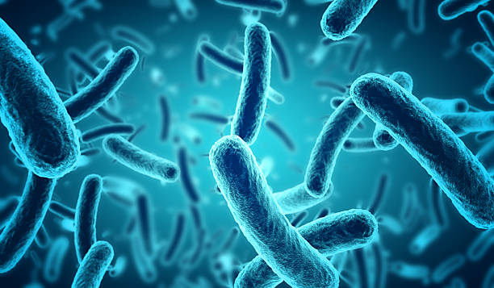

## **Intro**

**We need to classify 10 kinds of bacteria, using data obtrained genomic analysis technique:**

🦠 `Streptococcus_pyogenes`

🦠 `Salmonella_enterica`

🦠 `Enterococcus_hirae`

🦠 `Escherichia_coli`

🦠 `Campylobacter_jejuni`

🦠 `Streptococcus_pneumoniae`

🦠 `Staphylococcus_aureus`

🦠 `Escherichia_fergusonii`

🦠 `Bacteroides_fragilis`

🦠 `Klebsiella_pneumoniae`

`Metrics`: [categorization accuracy](https://developers.google.com/machine-learning/crash-course/classification/accuracy)  
`ML`: **classification**

## **About ACGT**

`ACGT` is an acronym for the four types of bases found in a DNA molecule:

- `adenine (A)`
- `cytosine (C)`
- `guanine (G)`
- `thymine (T)`

  A DNA molecule consists of two strands wound around each other, with each strand held together by bonds between the bases. Adenine pairs with thymine, and cytosine pairs with guanine. The sequence of bases in a portion of a DNA molecule, called a gene, carries the instructions needed to assemble a protein.</span>

[Learn more](https://www.genome.gov/about-genomics/fact-sheets/DNA-Sequencing-Fact-Sheet#:~:text=Sequencing%20DNA%20means%20determining%20the,make%20up%20the%20DNA%20molecule.&text=For%20example%2C%20scientists%20can%20use,turning%20genes%20on%20or%20off.)

```python
import numpy as np
import pandas as pd
import seaborn as sns
from matplotlib import pyplot as plt
from tqdm.notebook import tqdm
```

## **1. First steps**

**Go to Table of Content**

```python
def reduce_mem_usage(df, verbose=True):
    start_mem = df.memory_usage().sum()/1024**2
    numerics = ['int8', 'int16', 'int32', 'int64',
                'float16', 'float32', 'float64']

    for col in df.columns:
        if not col in ['row_id', 'target']:
            col_type = df[col].dtypes
            limit = abs(df[col]).max()

            for tp in numerics:
                cond1 = str(col_type)[0] == tp[0]
                if tp[0] == 'i': cond2 = limit <= np.iinfo(tp).max
                else: cond2 = limit <= np.finfo(tp).max

                if cond1 and cond2:
                    df[col] = df[col].astype(tp)
                    break

    end_mem = df.memory_usage().sum()/1024**2
    reduction = (start_mem - end_mem)*100/start_mem
    if verbose:
        print(f'[INFO] Mem. usage decreased to {end_mem:.2f}'
              f' MB {reduction:.2f}% reduction.')
    return df


df = pd.read_csv('../input/tabular-playground-series-feb-2022/train.csv')
df.drop('row_id', axis=1, inplace=True)

# df = reduce_mem_usage(df, verbose=True)
```

```python
df.head()
```

**No one missing value in the dataset**

```python
df.isnull().sum().sum()
```

**The sum of the sequence is always 10**

```python
import re
list_seq = df.columns.tolist()
check = []
for elem in list_seq[:-1]: #without target
    seq = re.sub(r'[A-Z]', '_', elem).split('_')
    seq = [int(elem) for elem in seq if elem != '']
    check.append(sum(seq))
print(f'max sum: {max(check)}, min sum: {min(check)}')
```

**Tnx to: https://www.kaggle.com/c/tabular-playground-series-feb-2022/discussion/304483**

**It makes sense to use 8 or even 10 features as categorial.**

```python
pd.DataFrame(df.nunique()).sort_values(0)[1:15]
```

```python
CATEG_FEATURES = pd.DataFrame(df.nunique()).sort_values(0)[1:11].index.tolist()
TARGET = ['target']
NUM_FEATURES = [feat for feat in df.columns if feat not in CATEG_FEATURES + TARGET]
```

**Descriptive statistics**

```python
df[NUM_FEATURES].describe().T.style.background_gradient(cmap='RdYlGn', subset=['mean', 'std', '25%', '50%', '75%'])\
                                   .bar(subset=['min'], color='tomato')\
                                   .bar(subset=['max'], color='lightgreen')\
                                   .format('{:.6f}')
```